# Final

logic for signal application

```r
dates <- sort(unique(all_signals_df$Date))
for(date in dates){
  daily_signals <- subset(all_signals_df, Date == date)

  equity <- getEndEq(Account = account.st, Date = date)
  total_inverse_sd <- sum(1 / daily_signals$SD)
  daily_signals$Weight <- (1 / daily_signals$SD) / total_inverse_sd
  daily_signals$Assigned_Cash <- daily_signals$Weight * equity*percentageTraded

  for (j in 1:nrow(daily_signals)) {
    pair <- daily_signals$Pair[j]
    entry_type <- daily_signals$EntryType[j]
    price <- daily_signals$Price[j]
    assigned_cash <- daily_signals$Assigned_Cash[j]
    quantity <- floor(assigned_cash / abs(price))

    if (entry_type == "compraSpreadBarato") {
      addTxn(Portfolio = portfolio.st, Symbol = pair, TxnDate = date, TxnPrice = price, TxnQty = -quantity, TxnFees = 0)
    } else if (entry_type == "vendeSpreadCaro") {
      addTxn(Portfolio = portfolio.st, Symbol = pair, TxnDate = date, TxnPrice = price, TxnQty = +quantity, TxnFees = 0)
    }
  }
  updatePortf(portfolio.st); updateAcct(account.st); updateEndEq(account.st)
}
```

Stats

```r
#medidas de retorno
myAccount <- getAccount(account.st)
myPortfolio <- getPortfolio(portfolio.st)
# Calculate daily equity PL
stats1 <- dailyStats(Portfolios = portfolio.st)
t(stats1)
```

```
               AAPL_MSFT.DailyEqPL AAPL_NVDA.DailyEqPL MSFT_AAPL.DailyEqPL
```

Total.Net.Profit -64374.20 -96566.62 -64374.20 Total.Days 1199.00 1287.00 1199.00 Winning.Days 610.00 664.00 610.00 Losing.Days 589.00 623.00 589.00 Avg.Day.PL -53.69 -75.03 -53.69 Med.Day.PL 2.50 47.49 2.50 Largest.Winner 25897.96 42123.91 25897.96 Largest.Loser -46949.50 -80752.95 -46949.50 Gross.Profits 1248790.46 3920354.16 1248790.46 Gross.Losses -1313164.66 -4016920.78 -1313164.66 Std.Dev.Daily.PL 4291.26 9543.19 4291.26 Percent.Positive 50.88 51.59 50.88 Percent.Negative 49.12 48.41 49.12 Profit.Factor 0.95 0.98 0.95 Avg.Win.Day 2047.20 5904.15 2047.20 Med.Win.Day 788.22 4129.17 788.22 Avg.Losing.Day -2229.48 -6447.71 -2229.48 Med.Losing.Day -871.50 -4134.45 -871.50 Avg.Daily.PL -53.69 -75.03 -53.69 Med.Daily.PL 2.50 47.49 2.50 Std.Dev.Daily.PL.1 4291.26 9543.19 4291.26 Skewness -1.73 -1.00 -1.73 Kurtosis 29.63 10.82 29.63 Ann.Sharpe -0.20 -0.12 -0.20 Max.Drawdown -143614.22 -467153.34 -143614.22 Profit.To.Max.Draw -0.45 -0.21 -0.45 Avg.WinLoss.Ratio 0.92 0.92 0.92 Med.WinLoss.Ratio 0.90 1.00 0.90 Max.Equity 35724.72 337172.36 35724.72 Min.Equity -142594.92 -129980.98 -142594.92 End.Equity -64374.20 -96566.62 -64374.20 MSFT_NVDA.DailyEqPL NVDA_AAPL.DailyEqPL NVDA_MSFT.DailyEqPL Total.Net.Profit 245157.19 -96566.62 224700.50 Total.Days 1322.00 1287.00 1322.00 Winning.Days 715.00 664.00 715.00 Losing.Days 607.00 623.00 607.00 Avg.Day.PL 185.44 -75.03 169.97 Med.Day.PL 225.06 47.49 210.81 Largest.Winner 36738.81 42123.91 33122.64 Largest.Loser -34970.92 -80752.95 -30492.82 Gross.Profits 3135170.21 3920354.16 2797654.63 Gross.Losses -2890013.01 -4016920.78 -2572954.13 Std.Dev.Daily.PL 6769.51 9543.19 5992.90 Percent.Positive 54.08 51.59 54.08 Percent.Negative 45.92 48.41 45.92 Profit.Factor 1.08 0.98 1.09 Avg.Win.Day 4384.85 5904.15 3912.80 Med.Win.Day 2537.45 4129.17 2297.35 Avg.Losing.Day -4761.14 -6447.71 -4238.80 Med.Losing.Day -2884.13 -4134.45 -2618.64 Avg.Daily.PL 185.44 -75.03 169.97 Med.Daily.PL 225.06 47.49 210.81 Std.Dev.Daily.PL.1 6769.51 9543.19 5992.90 Skewness -0.06 -1.00 -0.06 Kurtosis 4.12 10.82 4.05 Ann.Sharpe 0.43 -0.12 0.45 Max.Drawdown -211458.62 -467153.34 -185141.55 Profit.To.Max.Draw 1.16 -0.21 1.21 Avg.WinLoss.Ratio 0.92 0.92 0.92 Med.WinLoss.Ratio 0.88 1.00 0.88 Max.Equity 317412.50 337172.36 288637.37 Min.Equity -348.50 -129980.98 -348.50 End.Equity 245157.19 -96566.62 224700.50

```r
dailyPL <- dailyEqPL(Portfolios = portfolio.st)

#stats
tStats <- tradeStats(Portfolios = portfolio.st)
t(tStats)
```

```
               AAPL_MSFT     AAPL_NVDA     MSFT_AAPL     MSFT_NVDA
```

Portfolio “firststrat” “firststrat” “firststrat” “firststrat” Symbol “AAPL_MSFT” “AAPL_NVDA” “MSFT_AAPL” “MSFT_NVDA”  
Num.Txns “65” “53” “65” “44”  
Num.Trades “22” ” 7” “22” ” 9”  
Net.Trading.PL “-64374.20” “-96566.62” “-64374.20” “245157.19”  
Avg.Trade.PL “-5966.434” ” 6396.770” “-5966.434” ” 7164.654”  
Med.Trade.PL “-6970.675” ” 6523.809” “-6970.675” ” 7417.904”  
Largest.Winner ” 0.00” “12329.75” ” 0.00” “12112.72”  
Largest.Loser “-9541.418” ” 0.000” “-9541.418” ” 0.000”  
Gross.Profits ” 0.00” “44777.39” ” 0.00” “64481.89”  
Gross.Losses “-131261.6” ” 0.0” “-131261.6” ” 0.0”  
Std.Dev.Trade.PL “3116.529” “3053.707” “3116.529” “3118.365”  
Std.Err.Trade.PL ” 664.4462” “1154.1928” ” 664.4462” “1039.4548”  
Percent.Positive ” 0” “100” ” 0” “100”  
Percent.Negative “100” ” 0” “100” ” 0”  
Profit.Factor ” 0” NA ” 0” NA  
Avg.Win.Trade NA “6396.770” NA “7164.654”  
Med.Win.Trade NA “6523.809” NA “7417.904”  
Avg.Losing.Trade “-5966.434” NA “-5966.434” NA  
Med.Losing.Trade “-6970.675” NA “-6970.675” NA  
Avg.Daily.PL “-5966.434” ” 6396.770” “-5966.434” ” 7164.654”  
Med.Daily.PL “-6970.675” ” 6523.809” “-6970.675” ” 7417.904”  
Std.Dev.Daily.PL “3116.529” “3053.707” “3116.529” “3118.365”  
Std.Err.Daily.PL ” 664.4462” “1154.1928” ” 664.4462” “1039.4548”  
Ann.Sharpe “-30.39093” ” 33.25321” “-30.39093” ” 36.47276”  
Max.Drawdown “-143614.2” “-467153.3” “-143614.2” “-211458.6”  
Profit.To.Max.Draw “-0.4482439” “-0.2067129” “-0.4482439” ” 1.1593625” Avg.WinLoss.Ratio NA NA NA NA  
Med.WinLoss.Ratio NA NA NA NA  
Max.Equity ” 35724.72” “337172.36” ” 35724.72” “317412.50”  
Min.Equity “-142594.918” “-129980.977” “-142594.918” ” -348.496” End.Equity “-64374.20” “-96566.62” “-64374.20” “245157.19”  
NVDA_AAPL NVDA_MSFT  
Portfolio “firststrat” “firststrat” Symbol “NVDA_AAPL” “NVDA_MSFT”  
Num.Txns “53” “44”  
Num.Trades ” 7” ” 9”  
Net.Trading.PL “-96566.62” “224700.50”  
Avg.Trade.PL ” 6396.770” ” 7209.605”  
Med.Trade.PL ” 6523.809” ” 7417.904”  
Largest.Winner “12329.75” “12532.66”  
Largest.Loser ” 0.000” ” 0.000”  
Gross.Profits “44777.39” “64886.44”  
Gross.Losses ” 0.0” ” 0.0”  
Std.Dev.Trade.PL “3053.707” “3203.415”  
Std.Err.Trade.PL “1154.1928” “1067.8049”  
Percent.Positive “100” “100”  
Percent.Negative ” 0” ” 0”  
Profit.Factor NA NA  
Avg.Win.Trade “6396.770” “7209.605”  
Med.Win.Trade “6523.809” “7417.904”  
Avg.Losing.Trade NA NA  
Med.Losing.Trade NA NA  
Avg.Daily.PL ” 6396.770” ” 7209.605”  
Med.Daily.PL ” 6523.809” ” 7417.904”  
Std.Dev.Daily.PL “3053.707” “3203.415”  
Std.Err.Daily.PL “1154.1928” “1067.8049”  
Ann.Sharpe ” 33.25321” ” 35.72716”  
Max.Drawdown “-467153.3” “-185141.5”  
Profit.To.Max.Draw “-0.2067129” ” 1.2136687” Avg.WinLoss.Ratio NA NA  
Med.WinLoss.Ratio NA NA  
Max.Equity “337172.36” “288637.37”  
Min.Equity “-129980.977” ” -348.496” End.Equity “-96566.62” “224700.50”

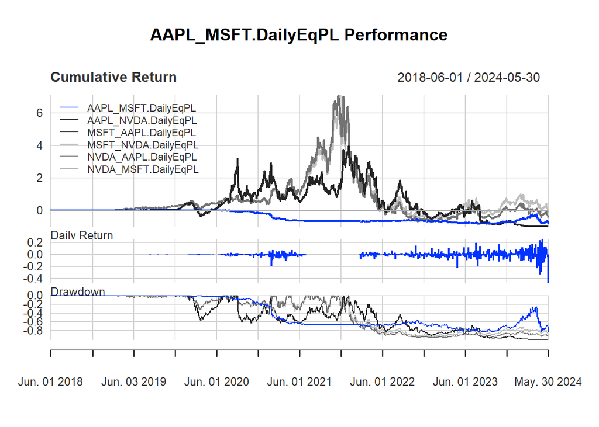

```r
port.Summ <- myPortfolio$summary
#returns
rets <- PortfReturns(Account = account.st)
rownames(rets) <- NULL
charts.PerformanceSummary(rets, colorset = bluefocus)
```

```r
initEq
```

[1] 1e+05

```r
getEndEq(account.st,to)
```

[1] 247976

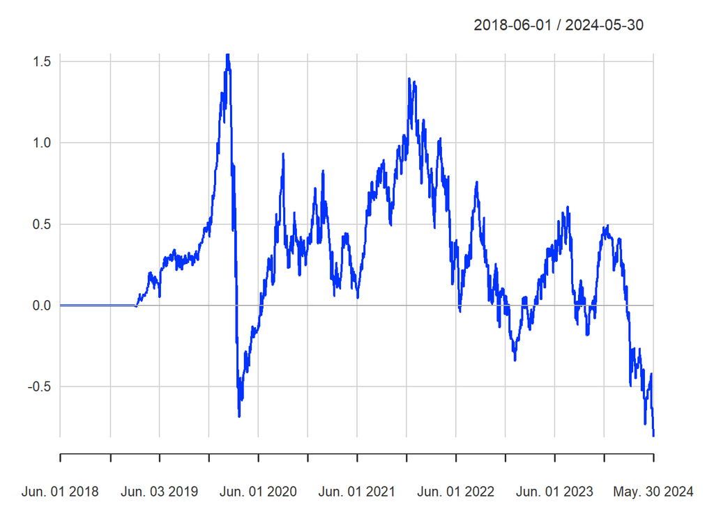

```r
retornosAcumulados <- cumsum(rets)
account.equity <- getAccount(account.st)$summary$End.Eq
portfolio.returns <- diff(log(account.equity))
portfolio.returns <- na.omit(portfolio.returns)
total_return <- cumsum(portfolio.returns)%>% tail(1)


annualized.sd <- StdDev.annualized(portfolio.returns)
max.drawdown <- maxDrawdown(portfolio.returns)
sharpe.ratio <- SharpeRatio.annualized(portfolio.returns, Rf = 0.01 / 252) # Asumiendo un 1% de tasa libre de riesgo anual

chart.CumReturns(portfolio.returns, colorset = bluefocus)
```